# IS THERE A CORRELATION BETWEEN CHANGES OF BITCOIN PRICE AND INDICATORS OF THE UK ECONOMY?

## 1. Introduction

### 1.1 Context

The creation of cryptocurrencies has changed how the world operates entirely. As a method of payment, a tool for investment or a mean for international transactions, cryptocurrencies now serve a fair number of purposes. Despite a few unsuccessful or at least not much popular attempts to create a cryptocurrency, Bitcoin is the first cryptocurrency to draw serious attention by market traders (Reif, 2021). Becoming a major tool for investment and trade online, Bitcoin has shown the strength to dictate many financial decisions from companies and from individuals alike (Graham, 2017). With larger and larger sums invested in cryptocurrencies by companies, it is to be expected that, with time, economies will be likely to influence how much cryptocurrencies cost on the global exchange. In an academic paper (Al.Qudah & Aloulou, 2020), researchers have studied how Bitcoin would serve as a tool for financial hedging in GCC countries. Data of inflation rate, foreign trade and GDP of those countries has been analysed alongside how Bitcoin has performed in the past. Being the 5th largest economy in the world for 2020 (Silver, 2021), it presents an interesting topic of research to test whether similar tendencies exist between Bitcoin and the country’s macroeconomic indicators. Following the concept of Al-Qudah and Aloulou (2020), this study will attempt in a similar fashion to analyse macroeconomic indicators of the UK economy parallel historical data on Bitcoin.

### 1.2 Factors for Time periods of Data

#### 1.2.1 Bitcoin

As the main object of analysis in this paper is the Bitcoin currency, its creation date must be taken into consideration. According to Investopedia, Bitcoin was created in January 2009 (Frankenfield, 2021). We can therefore use data since January 2009.

#### 1.2.2 UK Economic Indicators

As the second object of this study, the indicators of the UK Economy are available from the chosen data source for each financial year (Macrotrends.net). For example, if the study was to choose to examine periods between 2010 and 2019, this would yield ten pieces of data, one per year.

#### 1.2.3 Financial year

Because the scope of this paper targets the UK economic indicators, it must be taken into account the start and end date for the financial year in the UK so that the data periods can be set correctly. It is stated (“The UK Financial Year | What You Should Know”, 2022) that the financial year in the UK starts on 6th April and ends 5th April the following year. Meaning, if the year of data request was 2010, then the data should be from 6th April 2010 (inclusive) and until 5th April 2011 (inclusive).

#### 1.2.4 Covid-19

This study will attempt to stay away from analysing macroeconomic data and fluctuations of the Bitcoin currency market in the time periods when the pandemic would have taken place. According to news ("About the virus", 2022), the Coronavirus has been noticed by the end of 2019. This implies that the financial year 2019, from 6th April 2019 until 5th April 2020, would include data that has been afflicted by decisions based on upcoming pandemic assumptions. Such data will not be analysed with the aim to exclude distortions.

### 1.3 Data Sources and Data

The sources of the data used in this paper are credible platforms of cryptocurrency data and country macroeconomic data. They have been also chosen because of they allow data to be accessed. For the purpose of this paper, it aims to acquire data in two different ways: by reaching an API endpoint and by running a web scrape.

### 1.4 Limitations

#### 1.4.1 API calls

The CoinMarketCap API which is free for students has a maximum limit of 100 API calls per day (24 hours). However, the limit should prove enough to retrieve and analyse the data.

#### 1.4.2 API Character limit of response

The CoinMarketCap API has a limit of the response length of 100,000 characters.

#### 1.4.3 API Period between data Parameter

The CoinMarketCap API has a query parameter used to determine the time period between the dates of which historical data is returned. Because of the character limit of the response, the query will use the longest available period in order to retrieve the longest possible period of times to analyse in later stages.  
Example: if we query for 2 days, the results may contain data for 2 years, if we use the query for 4 days instead of 2 days, the results can stretch over a period of 4 years.  
The maximum period between data objects is 10 days. Unfortunately, this poses a challenge as, combined with the character limit, the response does not cover the necessary time span of 2009-2019 as intended earlier in the “Data Sources and Data” section of the paper. This presents a limitation of the current study.

### 1.5 Aims and Expectations

The aim of this study is to analyse macroeconomic data of the UK economy alongside the exchange prices of one Bitcoin cryptocurrency. The expectations are to find a general trend and correlation of the data between Bitcoin price and UK inflation. However, expectations do not anticipate a correlation between Bitcoin price and GDP and growth in GDP. No strong relationship is expected to be identified between changes in Bitcoin price and the aforementioned macroeconomic indicators for the UK.

### 1.6 Hypothesis

H0: There is a correlation between BTC price and UK inflation rate.  
H1: There is a correlation between BTC price and UK GDP.  
H2: There is a correlation between BTC price and UK Manufacturing output.  
H3: There is a correlation between BTC price and UK GNI per capita.  
Each macroeconomic indicator is used to form a separate hypothesis since some may fail while other may prove true.

### 1.7 Ethical considerations

#### 1.7.1 Method for acquiring data

##### CoinMarketCap

CoinMarketCap provides its registered users with an API key which can be used to make a certain number of API calls per day with a limited number of characters per query response. They officially state that this method is legal for its users to acquire data.

##### Macrotrends.net

Macrotrends provide tables with macroeconomic data of many countries. Their website is free to visit and the data is not restricted in any way to be used as long as it is not altered after referring to the website as a source. Web scraping is not mentioned in their terms and conditions section. By not having it banned in the terms and conditions, alongside the fact that the website does aim to make the data publicly available, web scrapping each of the required pages once will not pass legal boundaries set by the website for its data usage.

#### 1.7.2 Bias

##### CoinMarketCap

Their data is not affected by bias since it is historical financial data and has not been amended by CoinMarketCap in any way.

##### Macrotrends.net

The data is historical macroeconomic indicators and have not been altered by the website. Therefore, there is no chance for biased results.

## 2. Methodology

The methodology used in this paper consists of using the programming language Python in an environment suitable for making API calls, run code and print results in separate sections. This study will carry out empirical analysis (“What is empirical analysis?”, 2022) on available data online by calculating correlations between data series and make deductions based on data visualisation results. It will also execute hypothesis testing by estimating a number of values which provide insight on whether relationships between data series are significant or not. The values for hypothesis testing are Pearson's r, Spearman's rho and Kendall's tau (Stojiljkovic, n.d.).

### 2.1 Tools

The software used in this paper to retrieve and analyse the data to test the hypotheses will be:

```python
# Import libraries needed for project
import os
import requests
import json
import urllib3
import urllib
import pandas as pd
import matplotlib.pyplot as plt
import numpy as np
from bs4 import *
import scipy.stats
import seaborn as sb
# Set all graphs to a seaborn style with a grey background grid which makes reading graphs easier
sb.set()
```

## 3. Data

The data used for the analysis will be described in two separate sections, based on the method of retrieving the data and the type of data. The data on cryptocurrencies is retrieved via an API call, hence the section is defined “Data – API”, the data on UK macroeconomic indices is retrieved via web scraping, therefore the relevant section is named “Data – Table”.

### 3.1 Data – API

```python
# Information about CoinApi
# 'X-CoinAPI-Key': 'AEC34F97-E44C-49D9-9257-365CC2D59045',
# https://docs.coinapi.io/?python
# Get the historical exchange rates between two assets in the form of the timeseries.
# HTTP Request
# GET /v1/exchangerate/{asset_id_base}/{asset_id_quote}/history
```

#### 3.1.2 Functions

To create a request which the endpoint can process, the correct parameters must first be defined according to the data that needs to be returned.  
Then, in a separate function, the headers for the API call must be added as per the documentation in order for the endpoint to process the call successfully.  
The same function that makes the call can also handle any errors in the response from the server and notify the user.

#### 3.1.3 Data processing

The returned data from the GET request is processed using the json.loads() method to take a JSON string as an input and to return a Python object which can be later used.

```python
# define function to create parameterised query string for API call
# Example: https://rest.coinapi.io/v1/exchangerate/BTC/USD/history?period_id=1MIN&time_start=2016-01-01T00:00:00&time_end=2016-02-01T00:00:00
def getParamUrl():
    url = "https://rest.coinapi.io/v1/exchangerate/BTC/GBP/history?"
    params = { "period_id" : "10DAY", #max period is 10 day according to documentation
             "time_start" : "2010-04-06T00:00:00" ,
             "time_end" : "2019-04-05T00:00:00",
             'limit': '100000'}
    # financial year in UK starts 6th April and ends 5th April https://www.halkin.com/uk-financial-year#:~:text=When%20is%20the%20Start%20and,end%20until%205th%20April%202022.
    ## adjust api date start and end. To avoid covid data distortions, exclude Fy 2020 since by april 2020 covid had taken hold
    # Bitcoin was created late 2009 so we can start analyzing data at the start of the next FY   (2010)
    request = url + urllib.parse.urlencode(params)
    return request


# define function for API call
def getApiData(url):
    headers = {
        'Accepts': 'application/json',
        'X-CoinAPI-Key': 'AEC34F97-E44C-49D9-9257-365CC2D59045',
        'Accept-Encoding': 'deflate, gzip',
        'X-RateLimit-Limit': '1000000' ,
        'X-RateLimit-Remaining': '999989' ,
        'X-RateLimit-Request-Cost': '1'
    }
    try:
        response = requests.get(url, headers=headers)
        data = json.loads(response.text)
        return data
    except (ConnectionError, Timeout, TooManyRedirects) as e:
        print(e)
```

```python
# Send GET request to API endpoint
coinData = getApiData(getParamUrl())
coinData
```

[output not shown]

[output cut: 2169 more lines]

[output not shown]

Occasionally save the data into a separate file which can be used as a backup in case of data retrieving error or as an easier means of accessing data during future testing.

```python
# write contents into separeate file as backup and in case API or web scrape fails during marking review
f = open("coinData_raw.txt", "w")
f.write(str(coinData))
f.close()
```

#### 3.1.4 Creating a DataFrame and formatting data

By utilising the pandas library, the JSON string can be used to create a table (DataFrame) which takes columns and rows from the object’s properties.

```python
# convert received data into a Data Frame
df_coin = pd.DataFrame(coinData)
df_coin.to_csv('coinData_raw_DataFrame.csv', encoding='utf-8') # save as file for backup
df_coin
```

|  | time_period_start | time_period_end | time_open | time_close | rate_open | rate_high | rate_low | rate_close |
| --- | --- | --- | --- | --- | --- | --- | --- | --- |
| 0 | 2010-07-10T00:00:00.0000000Z | 2010-07-20T00:00:00.0000000Z | 2010-07-18T17:48:00.0000000Z | 2010-07-19T21:02:00.0000000Z | 0.037725 | 0.077353 | 0.025295 | 0.037750 |
| 1 | 2010-07-20T00:00:00.0000000Z | 2010-07-30T00:00:00.0000000Z | 2010-07-20T03:54:00.0000000Z | 2010-07-29T23:07:00.0000000Z | 0.053141 | 0.057517 | 0.028949 | 0.043077 |
| 2 | 2010-07-30T00:00:00.0000000Z | 2010-08-09T00:00:00.0000000Z | 2010-07-30T03:55:00.0000000Z | 2010-08-08T22:24:00.0000000Z | 0.044219 | 0.047888 | 0.029150 | 0.039928 |
| 3 | 2010-08-09T00:00:00.0000000Z | 2010-08-19T00:00:00.0000000Z | 2010-08-09T02:23:00.0000000Z | 2010-08-18T23:43:00.0000000Z | 0.039011 | 0.055053 | 0.031035 | 0.042049 |
| 4 | 2010-08-19T00:00:00.0000000Z | 2010-08-29T00:00:00.0000000Z | 2010-08-19T13:14:00.0000000Z | 2010-08-28T22:08:00.0000000Z | 0.041875 | 0.054859 | 0.031224 | 0.041668 |
| ... | ... | ... | ... | ... | ... | ... | ... | ... |
| 273 | 2017-12-30T00:00:00.0000000Z | 2018-01-09T00:00:00.0000000Z | 2017-12-30T00:01:00.0000000Z | 2018-01-08T23:59:00.0000000Z | 10985.669208 | 13716.528971 | 9114.647621 | 11420.702608 |
| 274 | 2018-01-09T00:00:00.0000000Z | 2018-01-19T00:00:00.0000000Z | 2018-01-09T00:01:00.0000000Z | 2018-01-18T23:59:00.0000000Z | 11396.285946 | 11988.969917 | 6877.543414 | 8520.512069 |
| 275 | 2018-01-19T00:00:00.0000000Z | 2018-01-29T00:00:00.0000000Z | 2018-01-19T00:01:00.0000000Z | 2018-01-28T23:59:00.0000000Z | 8503.707080 | 10016.117617 | 7270.720863 | 8802.783139 |
| 276 | 2018-01-29T00:00:00.0000000Z | 2018-02-08T00:00:00.0000000Z | 2018-01-29T00:01:00.0000000Z | 2018-02-07T23:59:00.0000000Z | 8800.808809 | 9042.981968 | 4421.746918 | 5717.766827 |
| 277 | 2018-02-08T00:00:00.0000000Z | 2018-02-18T00:00:00.0000000Z | 2018-02-08T00:01:00.0000000Z | 2018-02-17T23:59:00.0000000Z | 5776.141747 | 8757.738544 | 5674.738199 | 8539.527724 |

278 rows × 8 columns

#### 3.1.5 Data cleansing and formatting

Pandas also provides helpful methods of cleansing data.  
Firstly, the columns containing the data used in the analysis must not contain cells that are empty, i.e. do not have missing values. Any rows containing such empty cells in the specified columns will be opted out. This is done via the .notna() method.  
Secondly, to make the dates easier to read when plotted on a graph, the string containing the exact timestamp is trimmed down to the day being the lowest level of time definition.

```python
# take only rows where the rate_close column isnt empty or NaN
df_coin = df_coin[df_coin['rate_close'].notna()]
# Shorten string for time_period_start to make it year, month and day
df_coin['time_period_start'] = df_coin['time_period_start'].str.replace("T00:00:00.0000000Z","")
# keep only time_period_start and rate_close columns
df_coin = df_coin[["time_period_start", "rate_close"]]
# rename columns
df_coin = df_coin.rename(columns={"":"","time_period_start": "Year", "rate_close": "GBP per BTC"})
df_coin.to_csv('coinData_firstFormatting_DataFrame.csv', encoding='utf-8')
df_coin
```

|  | Year | GBP per BTC |
| --- | --- | --- |
| 0 | 2010-07-10 | 0.037750 |
| 1 | 2010-07-20 | 0.043077 |
| 2 | 2010-07-30 | 0.039928 |
| 3 | 2010-08-09 | 0.042049 |
| 4 | 2010-08-19 | 0.041668 |
| ... | ... | ... |
| 273 | 2017-12-30 | 11420.702608 |
| 274 | 2018-01-09 | 8520.512069 |
| 275 | 2018-01-19 | 8802.783139 |
| 276 | 2018-01-29 | 5717.766827 |
| 277 | 2018-02-08 | 8539.527724 |

278 rows × 2 columns

Afterwards, to be able to compare this data with macroeconomic indicators of the UK economy, it needs to be made average for each year. For this purpose, a dictionary with key value pairs is created to store each value of BTC price into its appropriate year, sum them up and devide by values each year. An average price of Bitcoin will be calculated for each year.

```python
# create dictionary with key value pairs for each financial year to store months and day values of GBP per BTC
yearly_prices = {"2010" : [],
                 "2011" : [],
                 "2012" : [],
                 "2013" : [],
                 "2014" : [],
                 "2015" : [],
                 "2016" : [],
                 "2017" : [],
                 "2018": []
                }

# loop over each key in the dictionary
for year in yearly_prices.keys():
    i = 0 # counter for the row we are looking at
    # loop over each cell in the Year column
    for cell in df_coin["Year"]:
        # if the year is contained in the cell, then add the GBP price of BTC for that time period to the relevant key in the dictionary
        if (year in cell) and (year == cell[:4]):
            # each key will now have all the prices of days and months for the year inside it.
            yearly_prices[year].append(df_coin["GBP per BTC"][i]) #use the i cell counter to get the price of the BTC
        i = i + 1 # go to next cell

yearly_prices
```

```
{'2010': [0.037749592121710515,
  0.04307676036832412,
  0.03992849404761904,
  0.04204859446398239,
  0.04166799290420679,
  0.03893218548617504,
  0.03596151354838709,
  0.03942048929663608,
  0.041973471455181204,
  0.06715690720951627,
  0.12198095361157771,
  0.23969119587811427,
  0.149538595810706,
  0.18542125400051468,
  0.13335057536162723,
  0.15945404016102768,
  0.1708687623954225,
  0.1930890945473251],
 '2011': [0.24694806538381958,
  0.26373983050847455,
  0.5170031913777245,
  0.6859322113914255,
  0.6329420669331952,
  0.5473155737704918,
  0.5280690904044408,
  0.543005959624569,
  0.46416150566413533,
  0.6504979114894283,
  1.0438806505582698,
  2.2019751455499414,
  4.609656761014152,
  5.300865545891937,
  11.999336562369912,
  12.810876854325581,
  10.356506624000003,
  8.587319762892335,
  8.78368639031043,
  8.730045543881028,
  5.749991850040749,
  6.361161172792363,
```

[output cut: 223 more lines]

```
  3718.391139624468,
  3765.8243421018124,
  4783.400287840926,
  4964.143307606571,
  5721.906633885058,
  6346.640731088261,
  7532.959485473443,
  11699.029923217722,
  13810.515305805407,
  11037.126165576927,
  11420.702607730584],
 '2018': [8520.512069165901,
  8802.783139006468,
  5717.76682706249,
  8539.527723983834]}
```

```python
# now the mean for each financial year needs to be calculated
#create new dictionary with average sums of BTC price for year
yearly_prices_avrg = {"2010" : [],
                 "2011" : [],
                 "2012" : [],
                 "2013" : [],
                 "2014" : [],
                 "2015" : [],
                 "2016" : [],
                 "2017" : [],
                 "2018": []
                }


# define function to sum up all items in list and devide by the length of the list
def Mean(List):
    return sum(List) / len(List)

# iterate over each key in dictionary
for key in yearly_prices.keys():
    yearly_prices_avrg[key].append(Mean(yearly_prices[key]))


yearly_prices_avrg
```

```
{'2010': [0.098961692926003],
 '2011': [3.723855761236246],
 '2012': [5.357119442731069],
 '2013': [42.95280218426246],
 '2014': [295.9976244086037],
 '2015': [212.54865031897378],
 '2016': [444.92701685045495],
 '2017': [3459.7489124445433],
 '2018': [7895.147439804674]}
```

The newly acquired average price of Bitcoin for each year is used to construct a DataFrame. This new Dataframe needs to undergo some formatting before being ready for future analysis.

```python
# convert dictionary into dataframe
df_coin_avrg = pd.DataFrame.from_dict(yearly_prices_avrg)
df_coin_avrg.to_csv('coinData_secondFormatting_DataFrame.csv', encoding='utf-8')
df_coin_avrg
```

|  | 2010 | 2011 | 2012 | 2013 | 2014 | 2015 | 2016 | 2017 | 2018 |
| --- | --- | --- | --- | --- | --- | --- | --- | --- | --- |
| 0 | 0.098962 | 3.723856 | 5.357119 | 42.952802 | 295.997624 | 212.54865 | 444.927017 | 3459.748912 | 7895.14744 |

```python
# transpose the dataframe so that years are rows instead of columns
df_coin_avrg = df_coin_avrg.transpose()
df_coin_avrg.to_csv('coinData_thirdFormatting_DataFrame.csv', encoding='utf-8')
df_coin_avrg
```

|  | 0 |
| --- | --- |
| 2010 | 0.098962 |
| 2011 | 3.723856 |
| 2012 | 5.357119 |
| 2013 | 42.952802 |
| 2014 | 295.997624 |
| 2015 | 212.548650 |
| 2016 | 444.927017 |
| 2017 | 3459.748912 |
| 2018 | 7895.147440 |

```python
# remove the years as the index
if df_coin_avrg.columns[0] != "index":
    df_coin_avrg.reset_index( level=0, inplace=True)
    print("Years are no longer the index for DataFrame")
else:
    print("First column is already a deindexed column so don't repeat the reset_index()")

df_coin_avrg
```

```
Years are no longer the index for DataFrame
```

|  | index | 0 |
| --- | --- | --- |
| 0 | 2010 | 0.098962 |
| 1 | 2011 | 3.723856 |
| 2 | 2012 | 5.357119 |
| 3 | 2013 | 42.952802 |
| 4 | 2014 | 295.997624 |
| 5 | 2015 | 212.548650 |
| 6 | 2016 | 444.927017 |
| 7 | 2017 | 3459.748912 |
| 8 | 2018 | 7895.147440 |

```python
# rename each column to relevant string
if (df_coin_avrg.columns[0] == "index" ) and (df_coin_avrg.columns[1] == 0 ):
    mapping = {"":"", "index":'Year', 0:'GBP per BTC'}
    df_coin_avrg = df_coin_avrg.rename(columns=mapping)
    print("Columns successfully renamed.")
else:
    print("Column names do not match the required strings to carry out rename() function.")

df_coin_avrg.to_csv('coinData_fourthFormatting_DataFrame.csv', encoding='utf-8')
df_coin_avrg
```

```
Columns successfully renamed.
```

|  | Year | GBP per BTC |
| --- | --- | --- |
| 0 | 2010 | 0.098962 |
| 1 | 2011 | 3.723856 |
| 2 | 2012 | 5.357119 |
| 3 | 2013 | 42.952802 |
| 4 | 2014 | 295.997624 |
| 5 | 2015 | 212.548650 |
| 6 | 2016 | 444.927017 |
| 7 | 2017 | 3459.748912 |
| 8 | 2018 | 7895.147440 |

This now represents the final version of the Average Bitcoin price per year DataFrame which will be used later. Now, it is time for the second data retrieving method - web scraping.

### 3.2 Data – Web Scrape

#### 3.2.1 Source - Macrotrends.net

The data for the UK macroeconomic indices will be retrieved from the macrotrends.net website by implementing a web scrapper. The website offers freely available data on each country’s factors of economic development. Historical data is available for each year, formatted and presented in tables. The web scrapper will iterate over several pages and target the appropriate table with data and return a list of its contents.

#### 3.2.2 Data Types

```python
# define function to take lxml data from scrapped page and create a data frame with it
def tableToDataFrame(table):
        col_names = ["index","1","2"]
        row = table.find("tr")
        columns = row.find_all(["td", "th"])
        for column in columns:
            text = column.find(text = True)
            text = text.strip()
            col_names.append(text)
        df = pd.DataFrame(columns = col_names)

        row_index = 0
        first_row = True

        for row in table.find_all("tr"):
            if first_row:
                first_row = False
                continue

            df.loc[row_index] = ""
            columns = row.find_all(["td", "th"])

            column_index = 1
            for column in columns:
                text = "".join(column.findAll(text=True, recursive="True")).strip()
                df.iat[row_index, column_index] = text
                column_index += 1
            row_index += 1
        return df
```

#### 3.2.4 Data processing

Followed by a definition of the scrapper() function which will use the http, urllib3 and beautifulsoup libraries to scrape any URLs given as input. It will then use the tableToDataFrame() function defined above to convert the soup object into a Dataframe which can be used to read the data easily.

```python
# function to take input url and scrape the table with contents
def scrapper(url):
    #pull the data from the webpage
    http = urllib3.PoolManager()
    response = http.request("GET", url)

    #create a beautiful soup object, pass in page data
    soup = BeautifulSoup(response.data, "lxml")

    #get the table items. There are 2 tables with same classes on the pages so we neeed the second one always. add [1]
    table = soup.findAll('table', { "class" : "historical_data_table table table-striped table-bordered"})[1]

    if  "gdp-per-capita" in url:
        f = open("gdp-per-capita_Data_raw.txt", "w")
        f.write(str(table))
        f.close()
    elif "manufacturing-output" in url:
        f = open("manufacturing-output_Data_raw.txt", "w")
        f.write(str(table))
        f.close()
    elif "inflation-rate-cpi" in url:
        f = open("inflation-rate-cpi_Data_raw.txt", "w")
        f.write(str(table))
        f.close()
    elif "gni-per-capita" in url:
        f = open("gni-per-capita_Data_raw.txt", "w")
        f.write(str(table))
        f.close()



    #use above defined function to convert data into a DataFrame and return it
    return tableToDataFrame(table)
```

#### 3.2.5 Data cleansing and formatting

```python
# define a sanitizer and formatting function based on each case url
def formatter(df, url):
    if  "gdp-per-capita" in url:

        df = df.iloc[1: , :]
        df = df.rename(columns={"index":"","1": "Year", "2": "GDP Per Capita USD", "U.K. GDP Per Capita - Historical Data": "Annual Growth Rate"})
        df['GDP Per Capita USD'] = df['GDP Per Capita USD'].str.replace('$','')
        df['GDP Per Capita USD'] = df['GDP Per Capita USD'].str.replace(',','').astype(int)
        df['Annual Growth Rate'] = df['Annual Growth Rate'].str.replace('%','').astype(float)

    elif "manufacturing-output" in url:

        df = df.iloc[1: , :]
        df = df.rename(columns={"index":"","1": "Year", "2": "Manufacturing Output in Billions USD", "U.K. Manufacturing Output - Historical Data": "Manufacturing Output as % of GDP"})
        df['Manufacturing Output in Billions USD'] = df['Manufacturing Output in Billions USD'].str.replace('$','')
        df['Manufacturing Output in Billions USD'] = df['Manufacturing Output in Billions USD'].str[:3].astype(int)
        df['Manufacturing Output as % of GDP'] = df['Manufacturing Output as % of GDP'].str.replace('%','').astype(float)

    elif "inflation-rate-cpi" in url:

        df = df.iloc[1: , :]
        df = df.rename(columns={"index":"","1": "Year", "2": "Inflation Rate %", "U.K. Inflation Rate - Historical Data": "Annual Change %"})
        df['Inflation Rate %'] = df['Inflation Rate %'].str.replace('%','').astype(float)
        df['Annual Change %'] = df['Annual Change %'].str.replace('%','').astype(float)

    elif "gni-per-capita" in url:

        df = df.iloc[1: , :]
        df = df.rename(columns={"index":"","1": "Year", "2": "GNI Per Capita USD", "U.K. GNI Per Capita - Historical Data": "Annual % Growth"})
        df['GNI Per Capita USD'] = df['GNI Per Capita USD'].str.replace('$','')
        df['GNI Per Capita USD'] = df['GNI Per Capita USD'].str.replace(',','').astype(int)
        df['Annual % Growth'] = df['Annual % Growth'].str.replace('%','').astype(float)

    else:
        print("None url conditions match. Problem.")
        return

    df = df[df["Year"] > "2009"]
    df = df[df["Year"] < "2019"]
    df = df.sort_values(by=['Year'], ascending=True)

    return df
```

Additionally, the scrapePages() function is defined which will take an input a list of URLs and then scrape each url and create a DataFrame of the desired contents for that page.  
Below the definition of this function, a list of all the URLs is created. This list is formatted for better readibility and will be used as input for the scrapePages function.

```python
# function to iterate over given list of urls, scrape them and return dataframes
def scrapePages(list):
    for page in list:

        df = scrapper(page)
        formattedDF = formatter(df, page)

        print(formattedDF)

        dataframes.append(formattedDF)
```

This is repeated for all pages containing the desired data. Each DataFrame is then used to create a single DataFrame which contains all the macroeconomic indicators.  
The merging for each of those DataFrames is carried out by the mergeDFrames() function.  
By separating this entire process into smaller functions, this analysis achieves a good level of SOC which can prove useful for reusability and debugging in the future.  
The DataFrame now contains only the required data in the correct form for further analysis.

```python
# to improve readability of pages in list below, defined a variable to hold the domain and the directory that doesnt change
base = "https://www.macrotrends.net/countries/GBR/united-kingdom/"

#append the page name to the above defined url
pages = [ base + "gdp-per-capita" ,
        base + "manufacturing-output" ,
        base + "inflation-rate-cpi" ,
        base + "gni-per-capita" ]

# list to hold dataframes of scraped pages
dataframes = []

#Grab dataframes and and merge them into one
def mergeDFrames(tables):
    # call scrapePages(pages) and pass the urls to scrappe. It will populate the dataframes list with dataframes to use below
    scrapePages(pages)

    #make the first dataframe the base which to merge others with
    combined = tables[0]

    i = 0

    # for each dataframe which isnt the first one, merge it with the base
    for frame in tables:
        if i > 0:
            combined = combined.merge(frame)
        i = i + 1
    return combined


df_macro = mergeDFrames(dataframes)

# save it locally
df_macro.to_csv('EconData_DataFrame.csv', encoding='utf-8')

df_macro
```

```
      Year  GDP Per Capita USD  Annual Growth Rate
11    2010               39537                2.07
10    2011               42048                6.35
9     2012               42449                0.95
8     2013               43401                2.24
7     2014               47452                9.33
6     2015               45039               -5.09
5     2016               41048               -8.86
4     2017               40306               -1.81
3     2018               42996                6.67
```

```
      Year  Manufacturing Output in Billions USD  \
11    2010                                   236
10    2011                                   249
9     2012                                   252
8     2013                                   265
7     2014                                   287
6     2015                                   274
5     2016                                   245
4     2017                                   242
3     2018                                   256

    Manufacturing Output as % of GDP
11                              9.53
10                              9.40
9                               9.33
```

[output cut: 26 more lines]

|  |  | Year | GDP Per Capita USD | Annual Growth Rate | Manufacturing Output in Billions USD | Manufacturing Output as % of GDP | Inflation Rate % | Annual Change % | GNI Per Capita USD | Annual % Growth |
| --- | --- | --- | --- | --- | --- | --- | --- | --- | --- | --- |
| 0 |  | 2010 | 39537 | 2.07 | 236 | 9.53 | 2.49 | 0.53 | 41740 | -5.63 |
| 1 |  | 2011 | 42048 | 6.35 | 249 | 9.40 | 3.86 | 1.36 | 41060 | -1.63 |
| 2 |  | 2012 | 42449 | 0.95 | 252 | 9.33 | 2.57 | -1.28 | 41690 | 1.53 |
| 3 |  | 2013 | 43401 | 2.24 | 265 | 9.54 | 2.29 | -0.28 | 42730 | 2.49 |
| 4 |  | 2014 | 47452 | 9.33 | 287 | 9.39 | 1.45 | -0.84 | 44400 | 3.91 |
| 5 |  | 2015 | 45039 | -5.09 | 274 | 9.35 | 0.37 | -1.08 | 44340 | -0.14 |
| 6 |  | 2016 | 41048 | -8.86 | 245 | 9.12 | 1.01 | 0.64 | 42940 | -3.16 |
| 7 |  | 2017 | 40306 | -1.81 | 242 | 9.11 | 2.56 | 1.55 | 41280 | -3.87 |
| 8 |  | 2018 | 42996 | 6.67 | 256 | 8.97 | 2.29 | -0.27 | 41740 | 1.11 |

Further formatting can drop any columns that are currently not useful for data comparison or which provide similar insight into fluctuations of the original indicators.

```python
df_macro = df_macro.drop(columns=["Year"])

df_macro["Year"]  = df_coin_avrg["Year"]

df_coin_macro = df_macro.merge(df_coin_avrg)

df_coin_macro = df_coin_macro.drop(columns=["Annual Growth Rate", "Annual Change %", "Manufacturing Output as % of GDP", "Annual % Growth"])

df_coin_macro.set_index("Year", inplace=True)

df_coin_macro.to_csv('AllData_values_DataFrame.csv', encoding='utf-8')

df_coin_macro
```

| Year |  | GDP Per Capita USD | Manufacturing Output in Billions USD | Inflation Rate % | GNI Per Capita USD | GBP per BTC |
| --- | --- | --- | --- | --- | --- | --- |
| 2010 |  | 39537 | 236 | 2.49 | 41740 | 0.098962 |
| 2011 |  | 42048 | 249 | 3.86 | 41060 | 3.723856 |
| 2012 |  | 42449 | 252 | 2.57 | 41690 | 5.357119 |
| 2013 |  | 43401 | 265 | 2.29 | 42730 | 42.952802 |
| 2014 |  | 47452 | 287 | 1.45 | 44400 | 295.997624 |
| 2015 |  | 45039 | 274 | 0.37 | 44340 | 212.548650 |
| 2016 |  | 41048 | 245 | 1.01 | 42940 | 444.927017 |
| 2017 |  | 40306 | 242 | 2.56 | 41280 | 3459.748912 |
| 2018 |  | 42996 | 256 | 2.29 | 41740 | 7895.147440 |

```python
#define lists we will need later

# the column names of the dataframe without the first index
colNames = df_coin_macro.columns.values.tolist()[1:]

# the column names of the dataframe without the first index and the last which is Bitcoin prices
colNamesMacro = df_coin_macro.columns.values.tolist()[1:5]

print(colNames)
print(colNamesMacro)
```

```
['GDP Per Capita USD', 'Manufacturing Output in Billions USD', 'Inflation Rate %', 'GNI Per Capita USD', 'GBP per BTC']
['GDP Per Capita USD', 'Manufacturing Output in Billions USD', 'Inflation Rate %', 'GNI Per Capita USD']
```

## 4. Analysis

### 4.1 Data Visualisation Raw Data

This study will attempt to plot the data of each variable and identify any potential visual relationships between the data, such as spikes or drops in the same year or same general trendline. For the purpose to determine if this method proves helpful, the visualisation will initially plot each values using a curve separately and together as well.

```
array([[<AxesSubplot:xlabel='Year'>, <AxesSubplot:xlabel='Year'>,
        <AxesSubplot:xlabel='Year'>],
       [<AxesSubplot:xlabel='Year'>, <AxesSubplot:xlabel='Year'>,
        <AxesSubplot:xlabel='Year'>],
       [<AxesSubplot:xlabel='Year'>, <AxesSubplot:xlabel='Year'>,
        <AxesSubplot:xlabel='Year'>]], dtype=object)
```

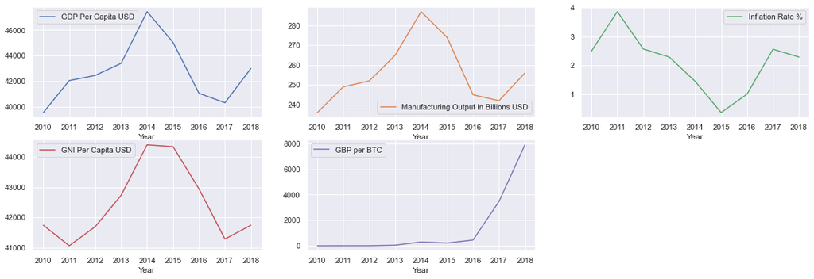

```python
df_coin_macro.reset_index().plot( x="Year" , layout=(3,3), figsize=(20, 10),subplots=True,sharex=False)
```

It is to be expected that the changes of all macroeconomic indicators can move simultaneously during the time period as they are tightly connected in representing the entire UK economy. However, the price of Bitcoin has an entirely different behaviour. The first years of the cryptocurrency show that its unpopularity leads to a steady low price, whereas, in the years nearing 2019, its price begins to exponentially grow upwards.  
Nevertheless, if these values are all plotted over each other in an attempt to compare trends, it is visible that due to huge differences in values, this method is rather unsuccessful to proving a hypothesis.

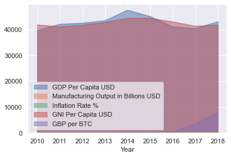

```python
df_coin_macro.plot.area(stacked=False);
```

Therefore, two new methods are going to be used from here on. One will be an empirical analysis which will look at correlations between column values. The second will be a repeated visualisation analysis but only after values are converted into a percentage change from the preceding year.

### 4.2 Empirical Analysis

#### 4.2.1 Correlation testing

The code below uses the .corr() method to calculate the correlation coefficient between the price of Bitcoin and each of the aforementioned macroeconomic data variables.  
Reading the results of each coefficient it can be deduced that:

```python
#Get correlation between columns
for macro in colNamesMacro:
    stat = df_coin_macro[macro].corr(df_coin_macro['GBP per BTC'])
    print("Correlation between values in " , macro , " and GBP per BTC is " , stat)
```

```
Correlation between values in  GDP Per Capita USD  and GBP per BTC is  -0.09007120221549049
Correlation between values in  Manufacturing Output in Billions USD  and GBP per BTC is  -0.1214535063177198
Correlation between values in  Inflation Rate %  and GBP per BTC is  0.09463526482135944
Correlation between values in  GNI Per Capita USD  and GBP per BTC is  -0.30728345010291847
```

#### 4.2.2 Pearson's r, Spearman's rho, Kendall's tau values testing

In the next series of tests, three coefficients are calculated to determine the relationship between each macroeconomic indicator the the price of Bitcoin. These are:

- Pearson's r.
- Spearman’s rho.
- Kendall’s Tau.

After calculating each, they are followed by correlation matrix which is just another way of obtaining and representing the correlation between values and also uses Pearson's r coefficient (Bock, n.d.).

```python
# carry out hypothesis testing based on correlation and values of r, rho and tau
for macro in colNamesMacro:
    if macro != "GBP per BTC":
        x = df_coin_macro[macro]
        y = df_coin_macro['GBP per BTC']

        r = scipy.stats.pearsonr(x, y)    # Pearson's r
        rho  = scipy.stats.spearmanr(x, y)   # Spearman's rho
        tau = scipy.stats.kendalltau(x, y)  # Kendall's tau

        print('\033[1m' + "Tests of BTC against", macro, "result in the following values:" + '\033[0m')
        print("Pearson's r = " , r)
        print("Spearman's rho = " , rho)
        print("Kendall's tau = " , tau)
        # https://realpython.com/numpy-scipy-pandas-correlation-python/#example-scipy-correlation-calculation

        #corrcoef() returns the correlation matrix, which is a two-dimensional array with the correlation coefficients.
        #The values on the main diagonal of the correlation matrix (upper left and lower right) are equal to 1. The upper left value corresponds to the correlation coefficient for x and x, while the lower right value is the correlation coefficient for y and y. They are always equal to 1.
        #However, what you usually need are the lower left and upper right values of the correlation matrix. These values are equal and both represent the Pearson correlation coefficient for x and y. In this case, it’s approximately 0.76.
        m = np.corrcoef(x, y)
        print("Correlation matrix is:")
        print(m)
        print()
        print()
```

```
Tests of BTC against GDP Per Capita USD result in the following values:
Pearson's r =  (-0.0900712022154905, 0.8177444575538041)
Spearman's rho =  SpearmanrResult(correlation=0.19999999999999998, pvalue=0.6059012741795533)
Kendall's tau =  KendalltauResult(correlation=0.2222222222222222, pvalue=0.47670855379188715)
Correlation matrix is:
[[ 1.        -0.0900712]
 [-0.0900712  1.       ]]


Tests of BTC against Manufacturing Output in Billions USD result in the following values:
Pearson's r =  (-0.12145350631771983, 0.755598233720507)
Spearman's rho =  SpearmanrResult(correlation=0.19999999999999998, pvalue=0.6059012741795533)
Kendall's tau =  KendalltauResult(correlation=0.2222222222222222, pvalue=0.47670855379188715)
Correlation matrix is:
[[ 1.         -0.12145351]
 [-0.12145351  1.        ]]


Tests of BTC against Inflation Rate % result in the following values:
Pearson's r =  (0.09463526482135938, 0.8086436537695062)
Spearman's rho =  SpearmanrResult(correlation=-0.4267819784654187, pvalue=0.2519566902874007)
Kendall's tau =  KendalltauResult(correlation=-0.3098898934004561, pvalue=0.24886387493792206)
Correlation matrix is:
[[1.         0.09463526]
 [0.09463526 1.        ]]


Tests of BTC against GNI Per Capita USD result in the following values:
Pearson's r =  (-0.30728345010291847, 0.42119492079575493)
Spearman's rho =  SpearmanrResult(correlation=0.23431167445160245, pvalue=0.5439670667628356)
Kendall's tau =  KendalltauResult(correlation=0.19720265943665385, pvalue=0.463071015014588)
Correlation matrix is:
[[ 1.         -0.30728345]
 [-0.30728345  1.        ]]
```

The paragraphs below explain the range of the values and what they means in terms of relationships between variables.

- The Pearson correlation coefficient r might be anything between +1 and -1. A value of 0 implies that the two variables have no relationship. A positive correlation is shown by a value larger than 0, whereas a negative association is indicated by a value less than 0 ("Pearson Product-Moment Correlation", n.d.).
- The correlation coefficients of Spearman's rho range from -1 to +1. A positive correlation of +1 implies that as one variable rises, the other tends to rise as well, and vice versa for negative correlations. Stronger links are represented by values near -1 or +1 than by values around zero (Frost, 2022).
- Kendall's Tau is a measure of data column relationships. The Tau correlation coefficient has a range of -1 to 1, with -1 denoting no relationship and 1 denoting a perfect one ("Kendall’s Tau - Simple Introduction", 2018). From the documentation it is visible the the default variant of the tau value is the Tau-b value, which is needed when analysing the data ("scipy.stats.kendalltau — SciPy v1.7.1 Manual", 2022). To determine if relationships are weak, moderate and strong, refer to (Mastrothanasis, 2020):  
  Less than + or - 0.10: very weak  
  + or -0.10 to 0.19: weak  
  + or - 0.20 to 0.29: moderate  
  + or - 0.30 or above: strong

Taking this into account, the following coefficients can be analysed:

##### 4.2.2.1 BTC against GDP Per Capita USD

- Pearson's r (-0.09) Not significant enough value to show positive or negative relationship.
- Spearman's rho (0.19) Not significant enough value to show positive or negative relationship, but slight tendency towards a positive relationship.
- Kendall's tau (0.22) Moderate positive relationship.

##### 4.2.2.2 BTC against Manufacturing Output in Billions USD

- Pearson's r (-0.12) Not significant enough value to show positive or negative relationship.
- Spearman's rho (0.19) Not significant enough value to show positive or negative relationship, but slight tendency towards a positive relationship.
- Kendall's tau (0.22) Moderate positive relationship.

##### 4.2.2.3 BTC against Inflation Rate %

- Pearson's r (0.09) Not significant enough value to show positive or negative relationship.
- Spearman's rho (-0.42) Negative value shows a somewhat negative relationship.
- Kendall's tau (-0.30) Strong negative relationship.

##### 4.2.2.4 BTC against GNI Per Capita USD

- Pearson's r (-0.30) Value shows a slight negative relationship.
- Spearman's rho (0.23) Not significant enough value to show positive or negative relationship, but slight tendency towards a positive relationship.
- Kendall's tau (0.19) Weak relationship.

#### 4.2.3 Percentage change visual analysis

```python
# for each column, calculated each new row's cell percentage change in value compared to previous
for col in colNames:
    #check if this has already ran. Otherwise many rows become NaN as a baseline for percentage comparison
    if col[0] != "NaN" :
        df_coin_macro[col] = df_coin_macro[col].pct_change()
        # in percent
        df_coin_macro[col] = df_coin_macro[col]*100

df_coin_macro = df_coin_macro.rename(columns={
    "Year":"Year","GDP Per Capita USD": "% Change in GDP Per Capita",
    "Manufacturing Output in Billions USD": "% Change in Manufacturing Output",
    "Inflation Rate %": "% Change in Inflation Rate",
    "GNI Per Capita USD" : "% Change in GNI Per Capita",
    "GBP per BTC" : "% Change in GBP per BTC"
})

df_coin_macro.to_csv('AllData_percentages_DataFrame.csv', encoding='utf-8')

df_coin_macro
```

| Year |  | % Change in GDP Per Capita | % Change in Manufacturing Output | % Change in Inflation Rate | % Change in GNI Per Capita | % Change in GBP per BTC |
| --- | --- | --- | --- | --- | --- | --- |
| 2010 |  | NaN | NaN | NaN | NaN | NaN |
| 2011 |  | 6.351013 | 5.508475 | 55.020080 | -1.629133 | 3662.926493 |
| 2012 |  | 0.953672 | 1.204819 | -33.419689 | 1.534340 | 43.859478 |
| 2013 |  | 2.242691 | 5.158730 | -10.894942 | 2.494603 | 701.789145 |
| 2014 |  | 9.333886 | 8.301887 | -36.681223 | 3.908261 | 589.122966 |
| 2015 |  | -5.085139 | -4.529617 | -74.482759 | -0.135135 | -28.192447 |
| 2016 |  | -8.861209 | -10.583942 | 172.972973 | -3.157420 | 109.329495 |
| 2017 |  | -1.807640 | -1.224490 | 153.465347 | -3.865859 | 677.599197 |
| 2018 |  | 6.673944 | 5.785124 | -10.546875 | 1.114341 | 128.200012 |

```python
#redefine lists

# the column names of the dataframe without the first index
colNames = df_coin_macro.columns.values.tolist()[1:]

# the column names of the dataframe without the first index and the last which is Bitcoin prices
colNamesMacro = df_coin_macro.columns.values.tolist()[1:5]

print(colNames)
print(colNamesMacro)
```

```
['% Change in GDP Per Capita', '% Change in Manufacturing Output', '% Change in Inflation Rate', '% Change in GNI Per Capita', '% Change in GBP per BTC']
['% Change in GDP Per Capita', '% Change in Manufacturing Output', '% Change in Inflation Rate', '% Change in GNI Per Capita']
```

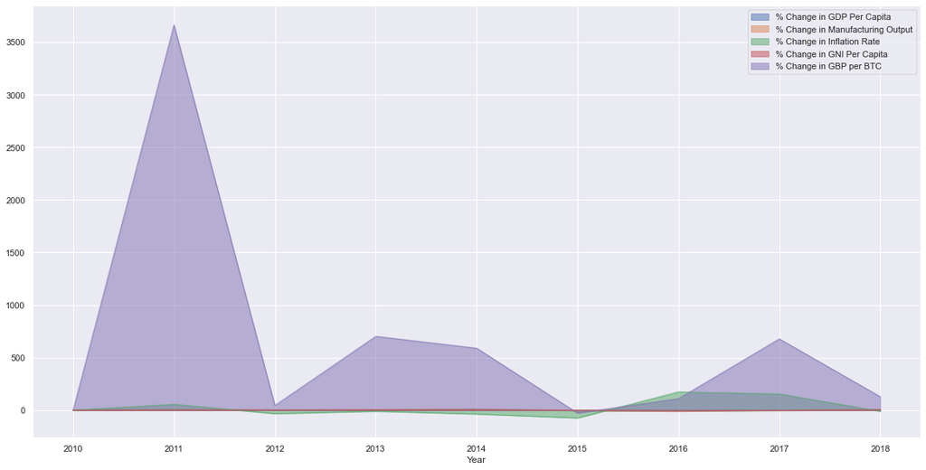

```python
df_coin_macro.plot.area(stacked=False , y = colNames, figsize=(20, 10)  );
```

Inspecting the graph above it can be deduced that because of the extremely low starting price of Bitcoin after its creation, as its price increases, the percentage change is really high, making it hard to acknowledge other data's movements along the timeline.  
Hence, plotting each variable separately may show better results.

```
array([[<AxesSubplot:xlabel='Year'>, <AxesSubplot:xlabel='Year'>],
       [<AxesSubplot:xlabel='Year'>, <AxesSubplot:xlabel='Year'>],
       [<AxesSubplot:xlabel='Year'>, <AxesSubplot:xlabel='Year'>]],
      dtype=object)
```

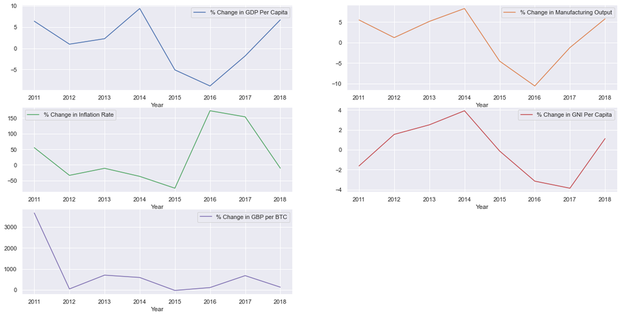

```python
df_coin_macro.reset_index().plot( x="Year" , y=colNames , layout=(3,2), figsize=(20, 10) , subplots=True , sharex=False)
```

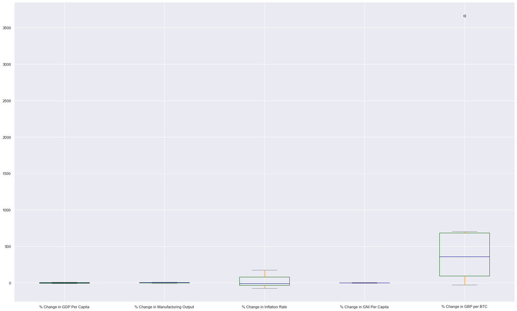

```python
color = {
    "boxes": "DarkGreen",
    "whiskers": "DarkOrange",
    "medians": "DarkBlue",
    "caps": "Gray",
}

df_coin_macro.plot.box( figsize=(26, 16)  , color=color,  y=colNames );
```

The box plot above shows that the median percentage changes of all macroeconomic indicators stay close to the 0 percent fluctuating above and below it by several points, whereas, the GBP per BTC median is at a substantial higher level at roughly 400 points. It is also visible that the first and third quartile of the BTC box are still high compared to the other variables, at approximately 100 and 700 points respectively. The BTC box also has an outlier at above 3500 which was the first year change also visible in previous graphs.

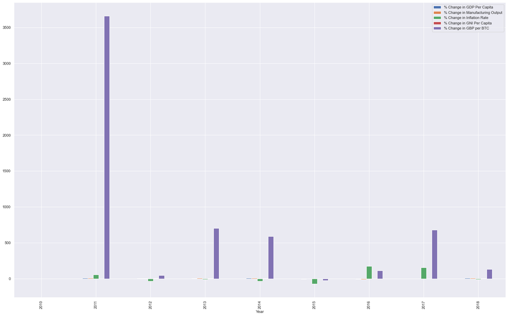

```python
df_coin_macro.plot.bar( y=colNames ,  figsize=(26, 16) );
```

The bar chart illustrates how independent BTC price changes are for the time period as their bar can be seen to be positive despite the negative bars of macroeconomic factors, in 2012 and 2013 for example.

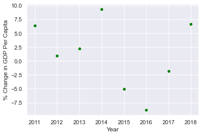

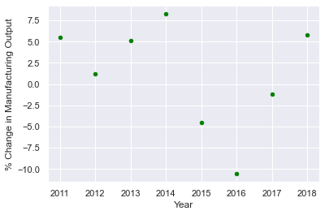

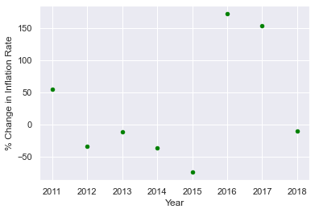

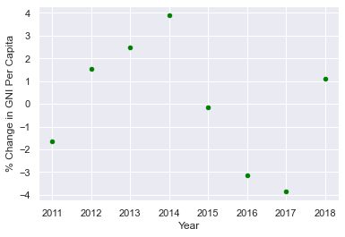

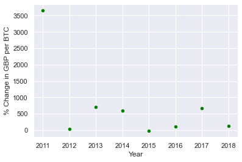

```python
#create a scatter plot of each macro column against BTC price
for col in colNames:
    df_coin_macro.reset_index().plot.scatter(x="Year", y= col , c='green');
```

The scatterplots above depict percentage changes during each year and show how different BTC moves compared to economic indicators. One clear message sent by the scatterplots is that Inflation is not so tightly related to the other three economic variables as their scatterplots are substantially different from one another, whereas GDP, GNI and Manufacturing have a similar overall look.

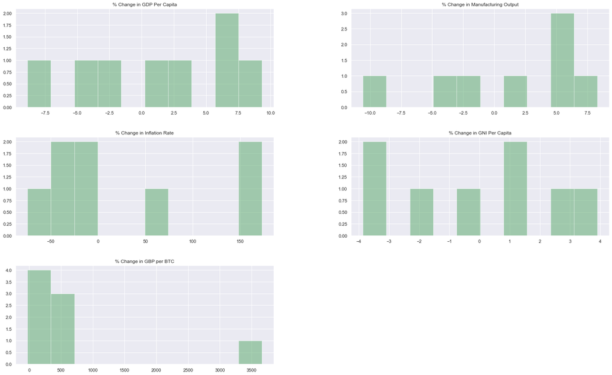

```python
df_coin_macro.hist(color="g", alpha=0.5, bins=10 , figsize=(26, 16));
```

## 5. Conclusion

### 5.2 Hypothesis testing

At the beginning of this study, these hypothesis were stated:  
H0: There is a correlation between BTC price and UK inflation rate.  
H1: There is a correlation between BTC price and UK GDP.  
H2: There is a correlation between BTC price and UK Manufacturing output.  
H3: There is a correlation between BTC price and UK GNI per capita.  
By analysing the data in two empirical ways and two stages of visualisation, it is made clear that the hypotheses do not pass and do, therefore, fail. Correlation tests and Pearson's r, Spearman's rho, Kendall's tau values show that no concise relationships exist between the macroeconomic indicators and the price of Bitcoin. The visual analysis also confirms this statement. Henceforth, this paper concludes the following:

- There is no correlation between BTC price and the UK macroeconomic indicators analysed above.

### 5.3 Implications for further research

This study does include some limitations to its methods of acquiring and analysing data. Potential future studies may be able to analyse more macroeconomic indicators of the UK rather than just four.  
Furthermore, it can prove more efficient to compare data which is on a monthly bases rather than on a yearly basis.  
In addition, the next comparison can also incorporate more types of cryptocurrencies and/or include more countries which rank in the top economies in the world, in an attempt to find a correlation between economies and prices of cryptocurrencies.

## 6. References

### 6.1 Theoretical & Conceptual resources

About the virus. (2022). Retrieved from https://www.euro.who.int/en/health-topics/health-emergencies/coronavirus-covid-19/novel-coronavirus-2019-ncov  
Al.Qudah, A., & Aloulou, M. (2020). Empirical Test For The Relationship Between The Bitcoin Using Historical Data With (Inflation Rate, Foreign Trade And GDP) And The Possibility To Use The Bitcoin As Hedge Against Inflation: Evidence From GCC Countries. JOURNAL OF SCIENTIFIC & TECHNOLOGY RESEARCH, 9(02). Retrieved from https://www.researchgate.net/publication/339626613_Empirical_Test_For_The_Relationship_Between_The_Bitcoin_Using_Historical_Data_With_Inflation_Rate_Foreign_Trade_And_GDP_And_The_Possibility_To_Use_The_Bitcoin_As_Hedge_Against_Inflation_Evidence_From_  
Bock, T. What is a Correlation Matrix? Retrieved from https://www.displayr.com/what-is-a-correlation-matrix/  
Frankenfield, J. (2021). Bitcoin Definition: How Does Bitcoin Work? Retrieved from https://www.investopedia.com/terms/b/bitcoin.asp#:~:text=Bitcoin%20is%20a%20decentralized%20digital,technology%20is%20still%20a%20mystery  
Frost, J. (2022). Spearman's Correlation Explained. Retrieved from https://statisticsbyjim.com/basics/spearmans-correlation/  
Graham, L. (2017). As bitcoin surges in price and popularity, so do the complaints. Retrieved from https://www.cnbc.com/2017/08/30/bitcoin-is-surging-in-price-and-popularity-but-so-are-the-complaints.html  
Kendall’s Tau - Simple Introduction. (2018). Retrieved from https://www.spss-tutorials.com/kendalls-tau/  
Mastrothanasis, K. (2020). Re: How can I make interpretation of Kendall's Tau-b correlation magnitude? Retrieved from: https://www.researchgate.net/post/How-can-I-make-interpretation-of-kendalls-Tau-b-correlation-magnitude/5fea3c6fb5d53e21916e64e8/citation/download  
Nickolas, S. (2021). What Do Correlation Coefficients Positive, Negative, and Zero Mean? Retrieved from https://www.investopedia.com/ask/answers/032515/what-does-it-mean-if-correlation-coefficient-positive-negative-or-zero.asp  
Pearson Product-Moment Correlation. Retrieved from https://statistics.laerd.com/statistical-guides/pearson-correlation-coefficient-statistical-guide.php  
Reif, N. (2021). Were There Cryptocurrencies Before Bitcoin? Retrieved from https://www.investopedia.com/tech/were-there-cryptocurrencies-bitcoin/  
Silver, C. (2021). The Top 25 Economies in the World. Retrieved from https://www.investopedia.com/insights/worlds-top-economies/#toc-5-united-kingdom  
The UK Financial Year | What You Should Know. (2022). Retrieved from https://www.halkin.com/uk-financial-year  
What is empirical analysis? (2022). Retrieved from https://whatis.techtarget.com/definition/empirical-analysis

### 6.2 Data Sources

Macrotrends. (2022). Retrieved from http://www.macrotrends.net/  
Most Trusted Cryptocurrency Market Data API | CoinMarketCap. (2022). Retrieved from https://coinmarketcap.com/api/

### 6.3 Technical Documentation

Matplotlib — Visualization with Python. (2022). Retrieved from https://matplotlib.org/  
NumPy. (2022). Retrieved from https://numpy.org/  
pandas - Python Data Analysis Library. (2022). Retrieved from https://pandas.pydata.org/  
requests. (2022). Retrieved from https://pypi.org/project/requests/  
Stojiljkovic, M. NumPy, SciPy, and Pandas: Correlation With Python. Retrieved from https://realpython.com/numpy-scipy-pandas-correlation-python/#example-scipy-correlation-calculation  
seaborn: statistical data visualization. (2022). Retrieved from https://seaborn.pydata.org/  
Beautiful Soup Documentation — Beautiful Soup 4.9.0 documentation. (2022). Retrieved from https://www.crummy.com/software/BeautifulSoup/bs4/doc/  
scipy.stats.kendalltau — SciPy v1.7.1 Manual. (2022). Retrieved from https://docs.scipy.org/doc/scipy/reference/generated/scipy.stats.kendalltau.html  
json — JSON encoder and decoder — Python 3.10.1 documentation. (2022). Retrieved from https://docs.python.org/3/library/json.html  
os — Miscellaneous operating system interfaces — Python 3.10.1 documentation. (2022). Retrieved from https://docs.python.org/3/library/os.html  
urllib3 1.26.7 documentation. (2022). Retrieved from https://urllib3.readthedocs.io/en/stable/